# Software Tools for Earth and Environmental Science

–7th WEEK–

Emir Toker

01/11/2019

## **R Language - Part 3**

- **Syllabus, Last Week and Book**
- **R Language - Part 1 and Part 2**
- **R Language - Part 3**
- **Workshop - MidTerm Project**
- **Next Week (not next, the other one)**

# **Syllabus, Last Week and Book**

## **Syllabus**

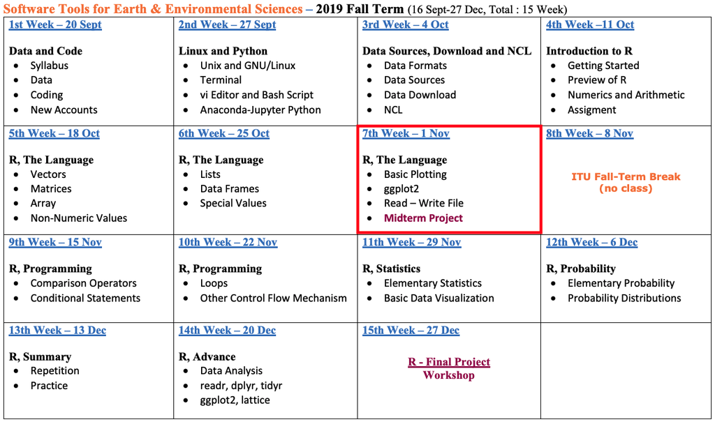

Extended Syllabus [PDF](https://web.itu.edu.tr/~tokerem/Software_Tools_Syllabus.pdf)

## **Last Week**

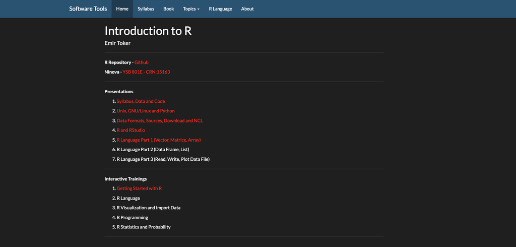

[LINK](https://emirtoker.github.io/Software_Tools_R_Github/)

## **Book**

[figure not shown]

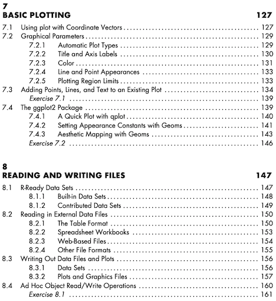

[PDF](https://web.itu.edu.tr/~tokerem/The_Book_of_R.pdf) - (Pg. 127-133 and 150-155)

# **R Language**

## **R Language - Part 1 & Part 2**

- **Basic Math, Assigment, Comment**
- **Data Types - Classes**
  - Numeric
  - Integer
  - Logical
  - Character
- **Data Structures - Objects**
  - Vector
  - Matrice
  - Array
  - Data Frame
  - List
- **Special Values, Attributes**

## **R Language - Part 3**

- **Read**
- **Write**
- **Plot**

# **R Language - Part 1 & 2**

## **Getting Started**

- Assignment; **<-**
- Comment; **#**
- Help; **?**func .or. **help(**func**)**
- Install Packages; install.packages()
- Call from Library; library()
- Basic Math;
  - addition; **+**
  - subtraction; **-**
  - multiplication; **`*`**
  - division; **/**
  - exponentiation; **^**
  - the square root; **sqrt**

## **Basic Math**

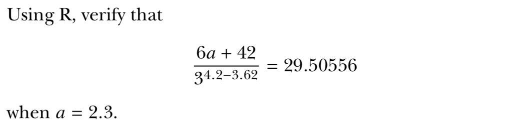

## **Basic Math**

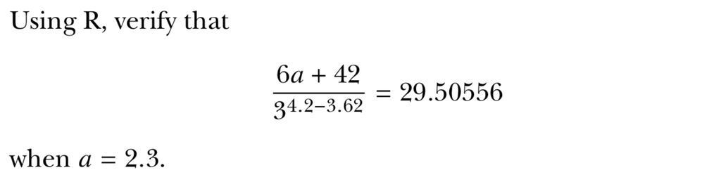

```r
a <- 2.3
(6*a+42)/(3^(4.2-3.62))
```

```
## [1] 29.50556
```

```r
isTRUE((6*a+42)/(3^(4.2-3.62))==29.50556)
```

```
## [1] FALSE
```

## **Scientific Math**

**Problem**: Compute double, triple or higher order integrals

## **Scientific Math**

**Problem**: Compute double, triple or higher order integrals

## **Scientific Math**

**Problem**: Compute double, triple or higher order integrals

```r
# install.packages("cubature")
library(cubature)

cube_f <- function(x) 1
adaptIntegrate(cube_f,lowerLimit = c(0,0,0),upperLimit = c(4,4,4))
```

```
## $integral
## [1] 64
##
## $error
## [1] 7.105427e-15
##
## $functionEvaluations
## [1] 33
##
## $returnCode
## [1] 0
```

## **Data Types - Classes**

- Numeric

```r
# Any number with (or without) a decimal point.
a <- 3
```

- Integer

```r
# Sub-class of the numeric class. The suffix L tells R to store.
a <- 3L
```

- Logical

```r
# TRUE or FALSE - Logical Operators. < , > , == , >= , <= , != ...
a <- 3<2
```

- Character

```r
# Data type consists of letters or words. String. with quotes: " … "
a <- "3"
```

**is.XXX()** and **class()**

## **Data Types - Classes**

```
name1 <- emir
name1 <- "emir"
name2 <- name1
name3 <- "name1"

number1 <- 32
number2 <- "32"
number3 <- 1:10
number4 <- seq(1,10)

var1 <- TRUE
var2 <- "TRUE"

answer1 <- is.logical(var1)
answer2 <- var1 + answer1 / 3
```

```
surname1 <- "toker"
print(name1)
print(surname1)

print(name1,surname1)
```

**is.XXX()** and **class()**

## **Data Structures - (Atomic) Vector**

```
name <- "emir"
surname <- "toker"

print(c(name,surname))     # c means “combine”
```

**Vector** : The simplest data structure in R

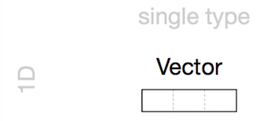

```
name <- "emir"
surname <- "toker"
name_surname <- c(name,surname)
length(name_surname)

print(c("21","21"))
print(c("21",21))
print(c(21,21))
```

## **Data Structures - (Atomic) Vector**

```
spring_months <- c("March", "April","May","June")

spring_months

length(spring_months)

dim(spring_months)

spring_months[1]

spring_months[3:4]

str(spring_months) # Structure

substr(spring_months, start = 1, stop = 3)  # Substrings

strsplit(spring_months,"")

gsub("a", "A", spring_months)   # Matching and Replacement
```

**?**str , **?**substr , **?**strsplit , **?**gsub

## **Data Structures - Matrice**

Vectors indexed using two indices instead of one.

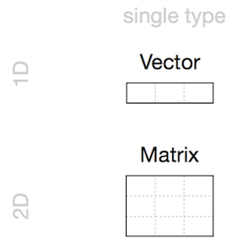

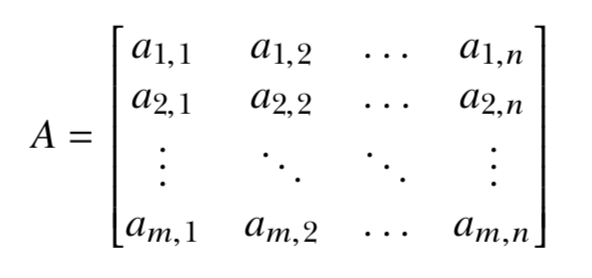

**[ row, col ]**

```r
a <- c(1:3)
# str(a) and dim(a) and length(a)
b <- matrix(1:3, nrow = 1, ncol = 3)
# str(b) and dim(b) and length(b)
```

## **Data Structures - Matrix**

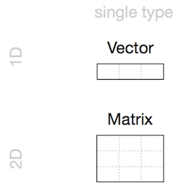

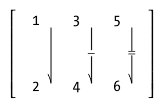

```r
a <- c(1:3)
b <- matrix(1:3, nrow = 1, ncol = 3)
```

```
## [1] 1 2 3
```

```
##      [,1] [,2] [,3]
## [1,]    1    2    3
```

```r
c <- matrix(1:9, nrow = 3, ncol = 3)
```

```
##      [,1] [,2] [,3]
## [1,]    1    4    7
## [2,]    2    5    8
## [3,]    3    6    9
```

```r
d <- matrix(1:9, nrow = 3, ncol = 3, byrow = TRUE)
```

```
##      [,1] [,2] [,3]
## [1,]    1    2    3
## [2,]    4    5    6
## [3,]    7    8    9
```

## **Data Structures - Matrix**

```r
my_mat <- matrix(runif(n=20, min=0, max=100), nrow = 4,  ncol = 5)
```

```
##          [,1]     [,2]      [,3]       [,4]     [,5]
## [1,] 87.45083 44.09112 40.167622 26.5740733 47.71724
## [2,] 99.05594 11.37408 32.373776 27.6868763 99.68139
## [3,] 65.02365 38.71510 55.799028 23.2332843 99.88472
## [4,] 90.60800 33.81055  7.519542  0.9259902 17.24921
```

```r
add <-  matrix(seq(from=10, to=60, by=10), nrow = 2, ncol = 3)
```

```
##      [,1] [,2] [,3]
## [1,]   10   30   50
## [2,]   20   40   60
```

```r
my_mat[2:3,2:4] <- add
```

```
##          [,1]     [,2]      [,3]       [,4]     [,5]
## [1,] 87.45083 44.09112 40.167622 26.5740733 47.71724
## [2,] 99.05594 10.00000 30.000000 50.0000000 99.68139
## [3,] 65.02365 20.00000 40.000000 60.0000000 99.88472
## [4,] 90.60800 33.81055  7.519542  0.9259902 17.24921
```

## **Data Structures - Array**

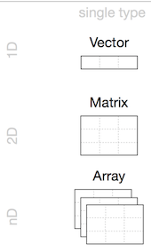

```r
str(arr)
```

[output not shown]

```r
# dim(arr)
# length(arr)
```

```r
x <- 1:24
```

```
##  [1]  1  2  3  4  5  6  7  8  9 10 11 12 13 14 15 16 17 18 19 20 21 22 23
## [24] 24
```

```r
arr <- array(x, dim = c(4,3,2)) #raw,col,level
```

```
## , , 1
##
##      [,1] [,2] [,3]
## [1,]    1    5    9
## [2,]    2    6   10
## [3,]    3    7   11
## [4,]    4    8   12
##
## , , 2
##
##      [,1] [,2] [,3]
## [1,]   13   17   21
## [2,]   14   18   22
## [3,]   15   19   23
## [4,]   16   20   24
```

## **Data Structures - Array**

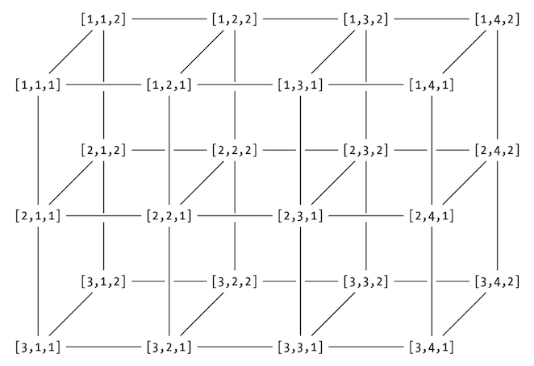

**[ row, col, level ]**

## **Data Structures - Array**

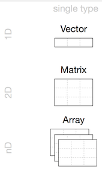

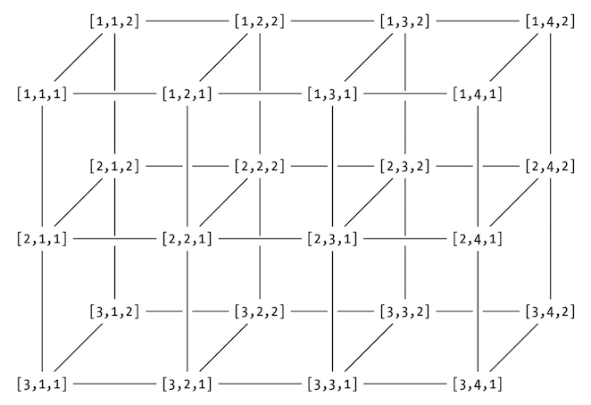

**[ row, col, level ]**

```r
arr <- array(data=10:30,dim=c(2,5,2))
```

```
## , , 1
##
##      [,1] [,2] [,3] [,4] [,5]
## [1,]   10   12   14   16   18
## [2,]   11   13   15   17   19
##
## , , 2
##
##      [,1] [,2] [,3] [,4] [,5]
## [1,]   20   22   24   26   28
## [2,]   21   23   25   27   29
```

```r
arr[2,2:4,1:2]
```

```
##      [,1] [,2]
## [1,]   13   23
## [2,]   15   25
## [3,]   17   27
```

```r
arr[1,1:5,2]
```

```
## [1] 20 22 24 26 28
```

## **Data Structures - Array**

```r
array <- array(data=seq(2,144,2),dim=c(3,6,4))
```

```
## , , 1
##
##      [,1] [,2] [,3] [,4] [,5] [,6]
## [1,]    2    8   14   20   26   32
## [2,]    4   10   16   22   28   34
## [3,]    6   12   18   24   30   36
##
## , , 2
##
##      [,1] [,2] [,3] [,4] [,5] [,6]
## [1,]   38   44   50   56   62   68
## [2,]   40   46   52   58   64   70
## [3,]   42   48   54   60   66   72
##
## , , 3
##
##      [,1] [,2] [,3] [,4] [,5] [,6]
## [1,]   74   80   86   92   98  104
## [2,]   76   82   88   94  100  106
## [3,]   78   84   90   96  102  108
##
## , , 4
##
##      [,1] [,2] [,3] [,4] [,5] [,6]
## [1,]  110  116  122  128  134  140
## [2,]  112  118  124  130  136  142
## [3,]  114  120  126  132  138  144
```

```
array[1,1,1:4]
array[1,1,]
array[1,1,4:1]
array[1,1,c(1:4!=2)]

array[1,1,2]
array[1,1,which(x==2)]
array[1,1,which(x<=2)]

array[1,1,2:4]
array[1,1,-1]
array[1,1,c(-1,-2)]

array[1,2:5,2]
array[1,c(2,3,4,5),2]
array[1,c(2,5),2]
```

```
array[1,c(2,5),2:3]
array[,c(2,5),2:3]
```

**[ row, col, level ]**

# **Data Structures (R-Objects)**

## **Data Structures (R-Objects)**

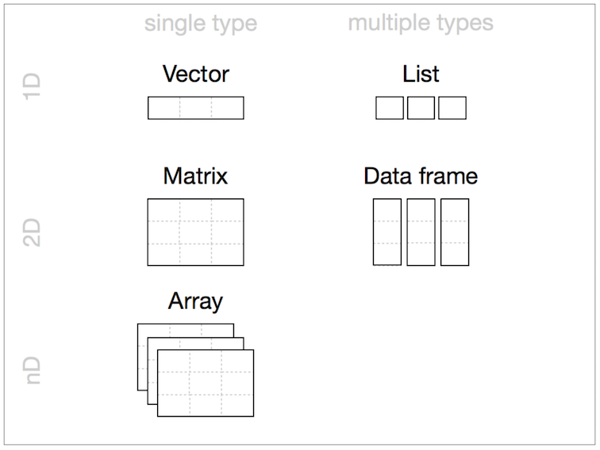

## **Data Structures (R-Objects)**

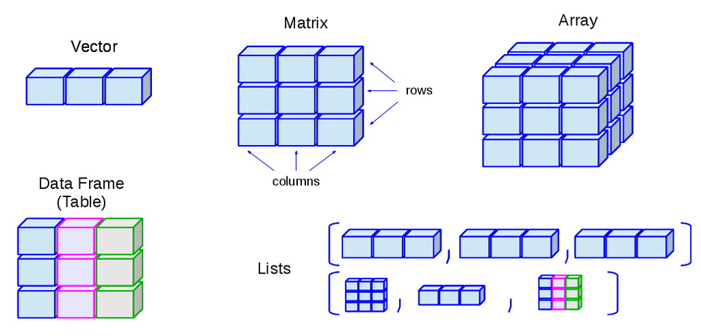

## **BONUS - Data Structures - Factor**

- Factors are a special variable type for storing categorical variables.
- They sometimes behave like strings, and sometimes like integers.

```
gender = c(male", "female", "male", "male", "female")
gender
class(gender)
str(gender)
gender[2]


gender_factor <- factor(c("male", "female", "male", "male", "female"))
gender_factor
class(gender_factor)
str(gender_factor)
gender_factor[2]
```

## **Data Structures - Data Frame**

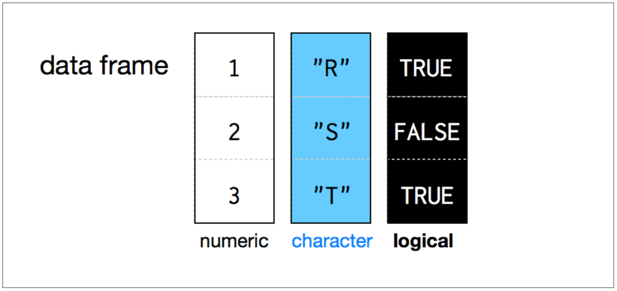

- Each element is of the same length, like a matrix.
- A column can have different types.
- BUT, all the elements within a column are the same type.

## **Data Structures - Data Frame**

```
person=c("Peter","Lois","Meg","Chris","Stewie")
age=c(42,40,17,14,1)
sex=factor(c("M","F","F","M","M"))
married=c(TRUE,TRUE,FALSE,FALSE,FALSE)

den <- matrix(c(person,married),5,2)
den <- matrix(c(age,married),5,2)
den <- matrix(c(person,age),5,2)
den <- matrix(c(person,sex),5,2)
```

no need to **Combine**

```
df <- data.frame(person,married)
df

class(df)
dim(df)
length(df)
str(df)
df$
df$person
as.character(df$person)

df <- data.frame(person,age,sex,married,stringsAsFactors=FALSE)
df
str(df)
```

## **Data Structures - Data Frame**

```
person="Brian"
age=7
sex=factor("M")
married=FALSE

new_record_row <- data.frame(person,age,sex,married)
new_df <- rbind(df,newrecord) # Combine R Objects by Rows


surname=c("Yilmaz","Zeki","Sahin","Caliskan","Uslu","Guzel")
new_record_col <- data.frame(surname, stringsAsFactors=FALSE)
new_df2 <- cbind(new_df, new_record_col) # Combine R Objects by Columns

new_df2
new_df2[c(5,6),]
new_df2[c(5,6),] <- new_df2[c(6,5),]
```

```
new_df2[5]

a <- 9:14
a
a[2]
a[2,]
b <- matrix(a,2,3)
b
b[2]
b[2,]
```

## **Data Structures - Data Frame**

```
new_df2
new_df2[1]
length(new_df2[1])
dim(new_df2[1])


new_df2[[1]]
length(new_df2[[1]])
dim(new_df2[[1]])

new_df2[[1]][2]
new_df2[[1]][2:5]

new_df2$person[2]
new_df2$person[2:5]
```

```
new_df2
new_df2[2:3,1:5]
new_df2[2:3,]

new_df2[2,1]
new_df2[2:2,1:1]

attributes(new_df2)
```

## **Data Structures - List**

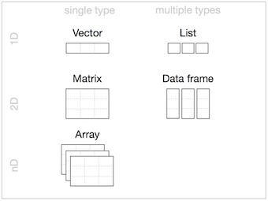

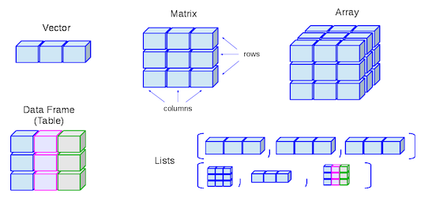

- Lists are like atomic vectors because they group data into a one-dimensional set.
- Lists are like data frame because they can group different types of data.
- BUT, the length of elements is NOT important.

## **Data Structures - List**

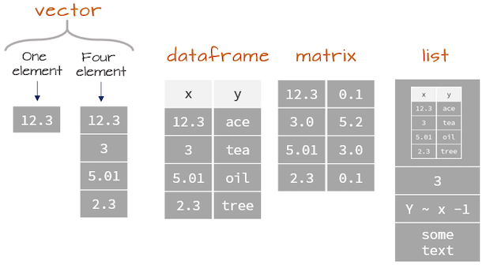

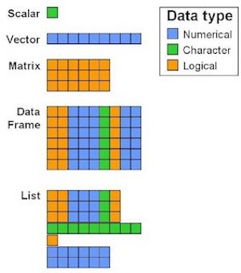

```
matrix <- matrix(data=1:4,nrow=2,ncol=2)
vector <- c(T,F,T,T)
var <- "hello"
data_frame <- new_df2

list  <- list(matrix,vector,var,data_frame)
class(list)
str(list)
dim(list)
length(list)
```

# **R Language - Part 3**

## **R Language - Part 3**

- **Read**
- **Write**
- **Plot**

## **Read**

```
library(help="datasets")
```

```
list.files("/Users/emirtoker/Desktop/Dersler/Memurluk/Software_Tools_for_Earth_&_Environmental_Science/Software_Tools_R_Github/Presentation")
```

```
file.choose()
```

```
read.table(file = "18397_Cekmekoy_Omerli_15dk_copy.txt")

read.table(file = "18397_Cekmekoy_Omerli_15dk.txt",
          header=TRUE, sep=";")

read.table(file = "18397_Cekmekoy_Omerli_15dk.txt",
          header=TRUE, sep=";", na.strings="-9999")

mydata_txt <- read.table(file = "18397_Cekmekoy_Omerli_15dk.txt",
                        header=TRUE,
                        sep=";",
                        na.strings="-9999")

str(mydatafile)
```

```
mydata_csv <- read.csv(file="18397_Cekmekoy_Omerli.csv",
                      header=TRUE,
                      na.strings="-9999")

str(mydata_csv)
```

## **Read and Write**

```
url <- "https://web.itu.edu.tr/tokerem/18397_Cekmekoy_Omerli_15dk.txt"
urldata_txt <- read.table(url,
                          header=TRUE,
                          sep=";",
                          na.strings="-9999")
```

Write .TXT and .CSV

```
write.table(x=urldata_txt,file="somenewfile.txt")

write.table(x=urldata_txt,file="somenewfile.txt",
           sep=";",na="-9999",quote=FALSE,row.names=FALSE)

new_df2
write.table(x=new_df2,file="dffile.txt",
            sep=";",na="-9999",quote=FALSE,row.names=FALSE)

write.table(x=new_df2,file="dffile.csv",
            sep=";",na="-9999",quote=FALSE,row.names=FALSE)
```

## **Plot**

```
foo <- c(1.1,2,3.5,3.9,4.2)
bar <- c(2,2.2,-1.3,0,0.2)
plot(foo,bar)
plot(foo,bar,type="l")
```

- **type** the supplied coordinates (for example, as stand-alone points or joined by lines or both dots and lines).
- **main, xlab, ylab** Options to include plot title, the horizontal axis label, and the vertical axis label, respectively.
- **col** Color (or colors) to use for plotting points and lines.
- **lty** Stands for line type. (for example, solid, dotted, or dashed).
- **lwd** This controls the thickness of plotted lines.
- **xlim, ylim** limits for the horizontal range and vertical range (respectively)

## **Workshop - Midterm Project**